# Statistical Brains: Neural Networks

Sanjiv Das

# Overview

Neural networks are special forms of nonlinear regressions where the decision system for which the NN is built mimics the way the brain is supposed to work (whether it works like a NN is up for grabs of course).

Terrific online book: http://neuralnetworksanddeeplearning.com/.

See my own book, which is a work-in-progress: http://srdas.github.io/DLBook/.

# Perceptrons

The basic building block of a neural network is a perceptron. A perceptron is like a neuron in a human brain. It takes inputs (e.g. sensory in a real brain) and then produces an output signal. An entire network of perceptrons is called a neural net.

For example, if you make a credit card application, then the inputs comprise a whole set of personal data such as age, sex, income, credit score, employment status, etc, which are then passed to a series of perceptrons in parallel. This is the first **layer** of assessment. Each of the perceptrons then emits an output signal which may then be passed to another layer of perceptrons, who again produce another signal. This second layer is often known as the **hidden** perceptron layer. Finally, after many hidden layers, the signals are all passed to a single perceptron which emits the decision signal to issue you a credit card or to deny your application.

Perceptrons may emit continuous signals or binary $(0,1)$ signals. In the case of the credit card application, the final perceptron is a binary one. Such perceptrons are implemented by means of **squashing** functions. For example, a really simple squashing function is one that issues a 1 if the function value is positive and a 0 if it is negative. More generally,

$$\begin{equation}
S(x) = \left\{
\begin{array}{cl}
1 & \mbox{if } g(x)>T \\
0 & \mbox{if } g(x) \leq T
\end{array}
\right.
\end{equation}$$

where $g(x)$ is any function taking positive and negative values, for instance, $g(x) \in (-\infty, +\infty)$. $T$ is a threshold level.

A neural network with many layers is also known as a **multi-layered** perceptron, i.e., all those perceptrons together may be thought of as one single, big perceptron.

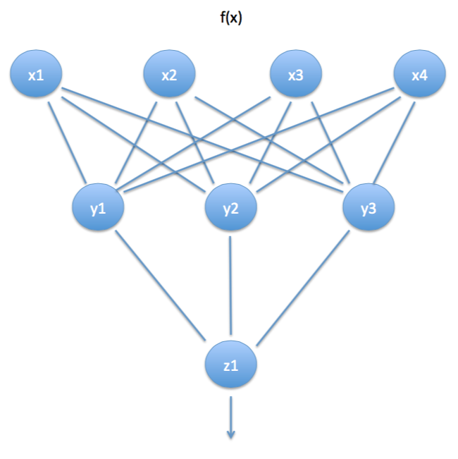

**x** is the input layer, **y** is the hidden layer, and **z** is the output layer.

# Deep Learning

Neural net models are related to **Deep Learning**, where the number of hidden layers is vastly greater than was possible in the past when computational power was limited. Now, deep learning nets cascade through 20-30 layers, resulting in a surprising ability of neural nets in mimicking human learning processes. see: http://en.wikipedia.org/wiki/Deep_learning

And also see: http://deeplearning.net/

# Binary NNs

Binary NNs are also thought of as a category of classifier systems. They are widely used to divide members of a population into classes. But NNs with continuous output are also popular. As we will see later, researchers have used NNs to learn the Black-Scholes option pricing model.

Areas of application: credit cards, risk management, forecasting corporate defaults, forecasting economic regimes, measuring the gains from mass mailings by mapping demographics to success rates.

# Squashing Functions

Squashing functions may be more general than just binary. They usually squash the output signal into a narrow range, usually $(0,1)$. A common choice is the logistic function (also known as the sigmoid function).

$$\begin{equation}
f(x) = \frac{1}{1+e^{-w\;x}}
\end{equation}$$

Think of $w$ as the adjustable weight. Another common choice is the probit function

$$\begin{equation}
f(x) = \Phi(w\;x)
\end{equation}$$

where $\Phi(\cdot)$ is the cumulative normal distribution function.

# How does the NN work?

The easiest way to see how a NN works is to think of the simplest NN, i.e. one with a single perceptron generating a binary output. The perceptron has $n$ inputs, with values $x_i, i=1...n$ and current weights $w_i, i=1...n$. It generates an output $y$.

The **net input** is defined as

$$\begin{equation}
\sum_{i=1}^n w_i x_i
\end{equation}$$

If a function of the net input is greater than a threshold $T$, then the output signal is $y=1$, and if it is less than $T$, the output is $y=0$. The actual output is called the **desired** output and is denoted $d = \{0,1\}$. Hence, the **training** data provided to the NN comprises both the inputs $x_i$ and the desired output $d$.

The output of our single perceptron model will be the sigmoid function of the net input, i.e.

$$\begin{equation}
y = \frac{1}{1+\exp\left( - \sum_{i=1}^n w_i x_i \right)}
\end{equation}$$

For a given input set, the error in the NN is given by some loss function, an example of which is below:

$$\begin{equation}
E = \frac{1}{2} \sum_{j=1}^m (y_j - d_j)^2
\end{equation}$$

where $m$ is the size of the training data set. The optimal NN for given data is obtained by finding the weights $w_i$ that minimize this error function $E$. Once we have the optimal weights, we have a calibrated **feed-forward** neural net.

For a given squashing function $f$, and input $x = [x_1, x_2, \ldots, x_n]'$, the multi-layer perceptron will given an output at each node of the hidden layer of

$$\begin{equation}
y(x) = f \left(w_0 + \sum_{j=1}^n w_j x_j \right)
\end{equation}$$

and then at the final output level the node is

$$\begin{equation}
z(x) = f\left( w_0 + \sum_{i=1}^N w_i \cdot f \left(w_{0i} + \sum_{j=1}^n w_{ji} x_j \right) \right)
\end{equation}$$

where the nested structure of the neural net is quite apparent. The $f$ functions are also known as **activation** functions.

# Relationship to Logit/Probit Models

The special model above with a single perceptron is actually nothing else than the logit regression model. If the squashing function is taken to the cumulative normal distribution, then the model becomes the probit regression model. In both cases though, the model is fitted by minimizing squared errors, not by maximum likelihood, which is how standard logit/probit models are parameterized.

# Connection to hyperplanes

Note that in binary squashing functions, the net input is passed through a sigmoid function and then compared to the threshold level $T$. This sigmoid function is a monotone one. Hence, this means that there must be a level $T'$ at which the net input $\sum_{i=1}^n w_i x_i$ must be for the result to be on the cusp. The following is the equation for a hyperplane

$$\begin{equation}
\sum_{i=1}^n w_i x_i = T'
\end{equation}$$

which also implies that observations in $n$-dimensional space of the inputs $x_i$, must lie on one side or the other of this hyperplane. If above the hyperplane, then $y=1$, else $y=0$. Hence, single perceptrons in neural nets have a simple geometrical intuition.

# Gradient Descent

We start with a simple function. We want to minimize this function. But let’s plot it first to see where the minimum lies.

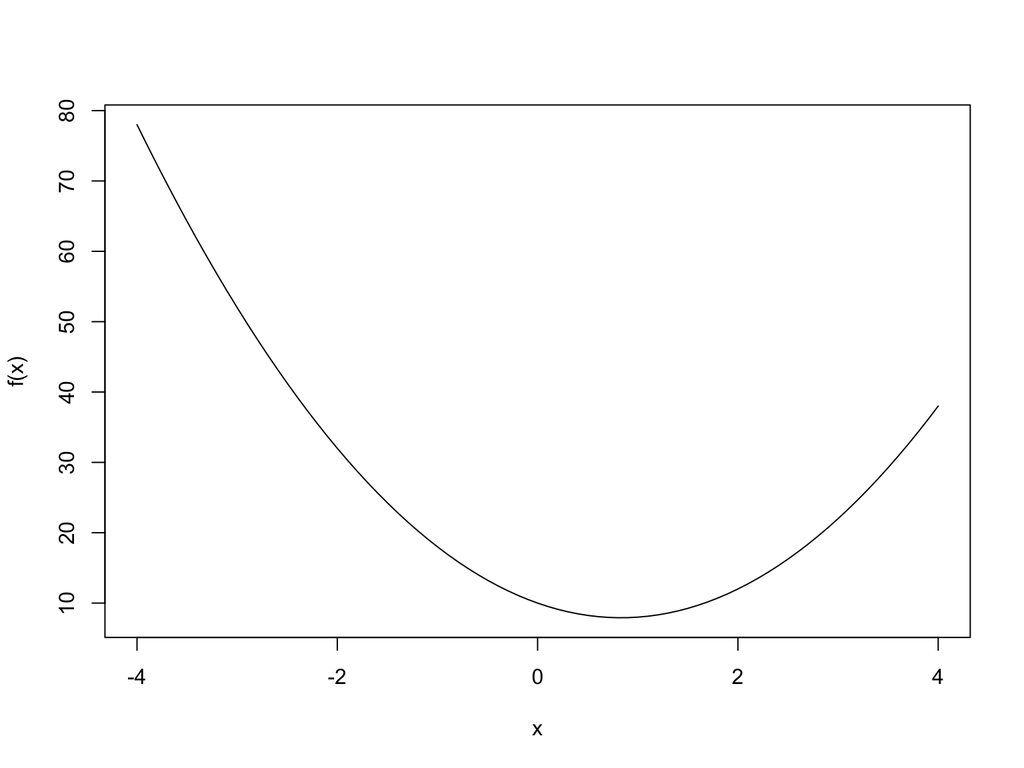

```r
f = function(x) { result = 3*x^2 - 5*x + 10 }
x = seq(-4,4,0.1)
plot(x,f(x),type="l")
```

Next, we solve for $x_{min}$, the value at which the function is minimized, which appears to lie between $0$ and $2$. We do this by gradient descent, from an initial value for $x=-3$. We then run down the function to its minimum but manage the rate of descent using a paramater $\eta=0.10$. The evolution (descent) equation is called recursively through the following dynamics for $x$:

$$x \leftarrow x - \eta \cdot \frac{\partial f}{\partial x}$$

If the gradient is positive, then we need to head in the opposite direction to reach the minimum, and hence, we have a negative sign in front of the modification term above. But first we need to calculate the gradient, and the descent. To repeat, first gradient, then descent!

```r
x = -3
eta = 0.10
dx = 0.0001
grad = (f(x+dx)-f(x))/dx
x = x - eta*grad
print(x)
```

```
## [1] -0.70003
```

We see that $x$ has moved closer to the value that minimizes the function. We can repeat thismany times till it settles down at the minimum, each round of updates being called an **epoch**. We run 20 epochs next.

```r
for (j in 1:20) {
  grad = (f(x+dx)-f(x))/dx
  x = x - eta*grad
  print(c(j,x,grad,f(x)))
}
```

```
## [1]  1.000000  0.219958 -9.199880  9.045355
## [1]  2.0000000  0.5879532 -3.6799520  8.0973009
## [1]  3.0000000  0.7351513 -1.4719808  7.9455858
## [1]  4.0000000  0.7940305 -0.5887923  7.9213008
## [1]  5.0000000  0.8175822 -0.2355169  7.9174110
## [1]  6.00000000  0.82700288 -0.09420677  7.91678689
## [1]  7.00000000  0.83077115 -0.03768271  7.91668636
## [1]  8.00000000  0.83227846 -0.01507308  7.91667000
## [1]  9.000000000  0.832881384 -0.006029233  7.916667279
## [1] 10.000000000  0.833122554 -0.002411693  7.916666800
## [1] 11.0000000000  0.8332190215 -0.0009646773  7.9166667059
## [1] 12.0000000000  0.8332576086 -0.0003858709  7.9166666839
## [1] 13.0000000000  0.8332730434 -0.0001543484  7.9166666776
## [1]  1.400000e+01  8.332792e-01 -6.173935e-05  7.916667e+00
## [1]  1.500000e+01  8.332817e-01 -2.469573e-05  7.916667e+00
## [1]  1.600000e+01  8.332827e-01 -9.878303e-06  7.916667e+00
## [1]  1.700000e+01  8.332831e-01 -3.951310e-06  7.916667e+00
## [1]  1.800000e+01  8.332832e-01 -1.580540e-06  7.916667e+00
## [1]  1.900000e+01  8.332833e-01 -6.322054e-07  7.916667e+00
## [1]  2.000000e+01  8.332833e-01 -2.528822e-07  7.916667e+00
```

It has converged really quickly! At convergence, the gradient goes to zero.

# Feedback and Backpropagation

What distinguishes neural nets from ordinary nonlinear regressions is feedback. Neural nets **learn** from feedback as they are used. Feedback is implemented using a technique called backpropagation.

Suppose you have a calibrated NN. Now you obtain another observation of data and run it through the NN. Comparing the output value $y$ with the desired observation $d$ gives you the error for this observation. If the error is large, then it makes sense to update the weights in the NN, so as to self-correct. This process of self-correction is known as **gradient descent** via **backpropagation**.

The benefit of gradient descent via backpropagation is that a full re-fitting exercise may not be required. Using simple rules the correction to the weights can be applied gradually in a learning manner.

Lets look at fitting with a simple example using a single perceptron. Consider the $k$-th perceptron. The sigmoid of this is

$$\begin{equation}
y_k = \frac{1}{1+\exp\left( - \sum_{i=1}^n w_{i} x_{ik} \right)}
\end{equation}$$

where $y_k$ is the output of the $k$-th perceptron, and $x_{ik}$ is the $i$-th input to the $k$-th perceptron. The error from this observation is $(y_k - d_k)$. Recalling that $E = \frac{1}{2} \sum_{j=1}^m (y_j - d_j)^2$, we may compute the change in error with respect to the $j$-th output, i.e.

$$\begin{equation}
\frac{\partial E}{\partial y_j} = y_j - d_j, \quad \forall j
\end{equation}$$

Note also that

$$\begin{equation}
\frac{dy_j}{dx_{ij}} = y_j (1-y_j) w_i
\end{equation}$$

and

$$\begin{equation}
\frac{dy_j}{dw_i} = y_j (1-y_j) x_{ij}
\end{equation}$$

Next, we examine how the error changes with input values:

$$\begin{equation}
\frac{\partial E}{\partial x_{ij}} = \frac{\partial E}{\partial y_j} \times \frac{dy_j}{dx_{ij}}
= (y_j - d_j) y_j (1-y_j) w_i
\end{equation}$$

We can now get to the value of interest, which is the change in error value with respect to the weights

$$\begin{equation}
\frac{\partial E}{\partial w_{i}} = \frac{\partial E}{\partial y_j} \times \frac{dy_j}{dw_i}
= (y_j - d_j)y_j (1-y_j) x_{ij}, \forall i
\end{equation}$$

We thus have one equation for each weight $w_i$ and each observation $j$. (Note that the $w_i$ apply across perceptrons. A more general case might be where we have weights for each perceptron, i.e., $w_{ij}$.) Instead of updating on just one observation, we might want to do this for many observations in which case the error derivative would be

$$\begin{equation}
\frac{\partial E}{\partial w_{i}} = \sum_j (y_j - d_j)y_j (1-y_j) x_{ij}, \forall i
\end{equation}$$

Therefore, if $\frac{\partial E}{\partial w_{i}} > 0$, then we would need to reduce $w_i$ to bring down $E$. By how much? Here is where some art and judgment is imposed. There is a tuning parameter $0<\gamma<1$ which we apply to $w_i$ to shrink it when the weight needs to be reduced. Likewise, if the derivative $\frac{\partial E}{\partial w_{i}} < 0$, then we would increase $w_i$ by dividing it by $\gamma$. This is known as **gradient descent**.

# Backpropagation

### Extension to many observations

Our notation now becomes extended to weights $w_{ik}$ which stand for the weight on the $i$-th input to the $k$-th perceptron. The derivative for the error becomes, across all observations $j$:

$$\begin{equation}
\frac{\partial E}{\partial w_{ik}} = \sum_j (y_j - d_j)y_j (1-y_j) x_{ikj}, \forall i,k
\end{equation}$$

Hence all nodes in the network have their weights updated. In many cases of course, we can just take the derivatives numerically. Change the weight $w_{ik}$ and see what happens to the error.

However, the formal process of finding all the gradients using a fast algorithm via backpropagation requires more formal calculus, and the rest of this section provides detailed analysis showing how this is done.

# Backprop: Detailed Analysis

In this section, we dig deeper into the incredible algebra that drives the unreasonable effectiveness of deep learning algorithms. To do this, we will work with a richer algebra, and extended notation.

### Net Input

Assume several hidden layers in a deep learning net (DLN), indexed by $r=1,2,...,R$. Consider two adjacent layers $(r)$ and $(r+1)$. Each layer as number of nodes $n_r$ and $n_{r+1}$, respectively.

The output of node $i$ in layer $(r)$ is $Z_i^{(r)} = f(a_i^{(r)})$. The function $f$ is the *activation* function. At node $j$ in layer $(r+1)$, these inputs are taken and used to compute an intermediate value, known as the *net value*:

$$a_j^{(r+1)} = \sum_{i=1}^{n_r} W_{ij}^{(r+1)}Z_i^{r} + b_j^{(r+1)}$$

### Activation Function

The net value is then ingested by an activation function to create the output from layer $(r+1)$.

$$Z_j^{(r+1)} = f(a_j^{(r+1)})$$

The activation functions may be simple sigmoid functions or other functions such as ReLU (Rectified Linear Unit). The final output of the DLN is from layer $(R)$, i.e., $Z_j^{(R)}$.

For the first hidden layer $r=1$, and the net input will be based on the original data $X^{(m)}$

$$a_j^{(1)} = \sum_{m=1}^M W_{mj}^{(1)} X_m + b_j^{(1)}$$

### Loss Function

Fitting the DLN is an exercise where the best weights $\{W,b\} = \{W_{ij}^{(r+1)}, b_j^{(r+1)}\},\forall r$ for all layers are determined to minimize a loss function generally denoted as

$$\min_{W,b} \sum_{m=1}^M L_m[h(X^{(m)}),T^{(m)}]$$

where $M$ is the number of training observations (rows in the data set), $T^{(m)}$ is the true value of the output, and $h(X^{(m)})$ is the model output from the DLN. The loss function $L_m$ quantifies the difference between the model output and the true output.

### Gradients

To solve this minimization problem, we need gradients for all $W,b$. These are denoted as

$$\frac{\partial L_m}{\partial W_{ij}^{(r+1)}}, \quad \frac{\partial L_m}{\partial b_{j}^{(r+1)}}, \quad \forall r+1, j$$

We write out these gradients using the chain rule:

$$\frac{\partial L_m}{\partial W_{ij}^{(r+1)}} = \frac{\partial L_m}{\partial a_j^{(r+1)}} \cdot \frac{\partial a_j^{(r+1)}}{\partial W_{ij}^{(r+1)}} = \delta_j^{(r+1)} \cdot Z_i^{(r)}$$

where we have written

$$\delta_j^{(r+1)} = \frac{\partial L_m}{\partial a_j^{(r+1)}}$$

Likewise, we have

$$\frac{\partial L_m}{\partial b_{j}^{(r+1)}} = \frac{\partial L_m}{\partial a_j^{(r+1)}} \cdot \frac{\partial a_j^{(r+1)}}{\partial b_{j}^{(r+1)}} = \delta_j^{(r+1)} \cdot 1 = \delta_j^{(r+1)}$$

### Delta Values

So we need to find all the $\delta_j^{(r+1)}$ values. To do so, we need the following intermediate calculation.

$$\begin{align}
a_j^{(r+1)} &= \sum_{i=1}^{n_r} W_{ij}^{(r+1)} Z_i^{(r)} + b_j^{(r+1)} \\
&= \sum_{i=1}^{n_r} W_{ij}^{(r+1)} f(a_i^{(r)}) + b_j^{(r+1)} \\
\end{align}$$

This implies that

$$\frac{\partial a_j^{(r+1)}}{\partial a_i^{(r)}} = W_{ij}^{(r+1)} \cdot f'(a_i^{(r)})$$

Using this we may now rewrite the $\delta$ value for layer $(r)$ as follows:

$$\begin{align}
\delta_i^{(r)} &= \frac{\partial L_m}{\partial a_i^{(r)}} \\
&= \sum_{j=1}^{n_{r+1}} \frac{\partial L_m}{\partial a_j^{(r+1)}} \cdot \frac{\partial a_j^{(r+1)}}{\partial a_i^{(r)}} \\
&= \sum_{j=1}^{n_{r+1}}\delta_j^{(r+1)} \cdot W_{ij}^{(r+1)} \cdot f'(a_i^{(r)}) \\
&= f'(a_i^{(r)}) \cdot \sum_{j=1}^{n_{r+1}}\delta_j^{(r+1)} \cdot W_{ij}^{(r+1)}
\end{align}$$

### Output layer

The output layer takes as input the last hidden layer ${(R)}$’s output $Z_j^{(R)}$, and computes the net input $a_j^{(R+1)}$ and then the activation function $h(a_j^{(R+1)})$ is applied to generate the final output.

$$\begin{align}
a_j^{(R+1)} &= \sum_{i=1}^{n_R} W_{ij}^{(R+1)} Z_j^{(R)} + b_j^{(R+1)} \\
\mbox{Final output} &= h(a_j^{(R+1)})
\end{align}$$

The $\delta$ for the final layer is simple.

$$\delta_j^{(R+1)} = \frac{\partial L_m}{\partial a_j^{(R+1)}} = h'(a_j^{(R+1)})$$

### Feedforward and Backward Propagation

Fitting the DLN requires getting the weights $\{W,b\}$ that minimize $L_m$. These are done using gradient descent, i.e.,

$$\begin{align}
W_{ij}^{(r+1)} \leftarrow W_{ij}^{(r+1)} - \eta \cdot \frac{\partial L_m}{\partial W_{ij}^{(r+1)}} \\
b_{j}^{(r+1)} \leftarrow b_{j}^{(r+1)} - \eta \cdot \frac{\partial L_m}{\partial b_{j}^{(r+1)}}
\end{align}$$

Here $\eta$ is the learning rate parameter. We iterate on these functions until the gradients become zero, and the weights discontinue changing with each update, also known as an **epoch**.

The steps are as follows:

1. Start with an initial set of weights $\{w,b\}$.
2. Feedforward the initial data and weights into the DLN, and find the $\{a_i^{(r)}, Z_i^{(r)}\}, \forall r,i$. This is one forward pass through the network.
3. Then, using backpropagation, compute all $\delta_i^{(r)}, \forall r,i$.
4. Use these $\delta_i^{(r)}$ values to get all the new gradients.
5. Apply gradient descent to get new weights.
6. Keep iterating steps 2-5, until the chosen number of epochs is completed.

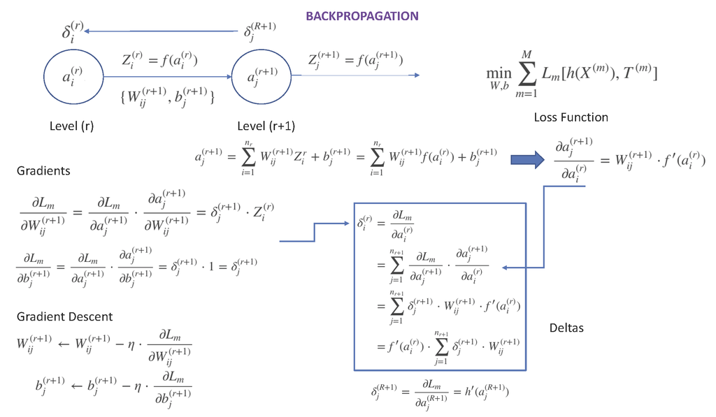

Quick Summary of Backpropagation

# Research Applications

- Discovering Black-Scholes: See the paper by @RePEc:bla:jfinan:v:49:y:1994:i:3:p:851-89, A Nonparametric Approach to Pricing and Hedging Securities Via Learning Networks, The Journal of Finance, Vol XLIX.
- Forecasting: See the paper by @CIS-201490. “A dynamic artificial neural network model for forecasting time series events,” International Journal of Forecasting 21, 341–362.

# Package *neuralnet* in R

The package focuses on multi-layer perceptrons (MLP), see Bishop (1995), which are well applicable when modeling functional relation- ships. The underlying structure of an MLP is a directed graph, i.e. it consists of vertices and directed edges, in this context called neurons and synapses. See Bishop (1995), Neural networks for pattern recognition. Oxford University Press, New York.

The data set used by this package as an example is the infert data set that comes bundled with R.

This data set examines infertility after induced and spontaneous abortion. The variables **induced** and **spontaneous** take values in $\{0,1,2\}$ indicating the number of previous abortions. The variable **parity** denotes the number of births. The variable **case** equals 1 if the woman is infertile and 0 otherwise. The idea is to model infertility.

```r
library(neuralnet)
data(infert)
print(names(infert))
```

```
## [1] "education"      "age"            "parity"         "induced"
## [5] "case"           "spontaneous"    "stratum"        "pooled.stratum"
```

```r
head(infert)
```

```
##   education age parity induced case spontaneous stratum pooled.stratum
## 1    0-5yrs  26      6       1    1           2       1              3
## 2    0-5yrs  42      1       1    1           0       2              1
## 3    0-5yrs  39      6       2    1           0       3              4
## 4    0-5yrs  34      4       2    1           0       4              2
## 5   6-11yrs  35      3       1    1           1       5             32
## 6   6-11yrs  36      4       2    1           1       6             36
```

```r
summary(infert)
```

```
##    education        age            parity         induced
##  0-5yrs : 12   Min.   :21.00   Min.   :1.000   Min.   :0.0000
##  6-11yrs:120   1st Qu.:28.00   1st Qu.:1.000   1st Qu.:0.0000
##  12+ yrs:116   Median :31.00   Median :2.000   Median :0.0000
##                Mean   :31.50   Mean   :2.093   Mean   :0.5726
##                3rd Qu.:35.25   3rd Qu.:3.000   3rd Qu.:1.0000
##                Max.   :44.00   Max.   :6.000   Max.   :2.0000
##       case         spontaneous        stratum      pooled.stratum
##  Min.   :0.0000   Min.   :0.0000   Min.   : 1.00   Min.   : 1.00
##  1st Qu.:0.0000   1st Qu.:0.0000   1st Qu.:21.00   1st Qu.:19.00
##  Median :0.0000   Median :0.0000   Median :42.00   Median :36.00
##  Mean   :0.3347   Mean   :0.5766   Mean   :41.87   Mean   :33.58
##  3rd Qu.:1.0000   3rd Qu.:1.0000   3rd Qu.:62.25   3rd Qu.:48.25
##  Max.   :1.0000   Max.   :2.0000   Max.   :83.00   Max.   :63.00
```

This data set examines infertility after induced and spontaneous abortion. The variables ** induced** and **spontaneous** take values in $\{0,1,2\}$ indicating the number of previous abortions. The variable **parity** denotes the number of births. The variable **case** equals 1 if the woman is infertile and 0 otherwise. The idea is to model infertility.

### First step, fit a logit model to the data.

```r
res = glm(case ~ age+parity+induced+spontaneous, family=binomial(link="logit"), data=infert)
summary(res)
```

```
##
## Call:
## glm(formula = case ~ age + parity + induced + spontaneous, family = binomial(link = "logit"),
##     data = infert)
##
## Deviance Residuals:
##     Min       1Q   Median       3Q      Max
## -1.6281  -0.8055  -0.5299   0.8669   2.6141
##
## Coefficients:
##             Estimate Std. Error z value Pr(>|z|)
## (Intercept) -2.85239    1.00428  -2.840  0.00451 **
## age          0.05318    0.03014   1.764  0.07767 .
## parity      -0.70883    0.18091  -3.918 8.92e-05 ***
## induced      1.18966    0.28987   4.104 4.06e-05 ***
## spontaneous  1.92534    0.29863   6.447 1.14e-10 ***
## ---
## Signif. codes:  0 '***' 0.001 '**' 0.01 '*' 0.05 '.' 0.1 ' ' 1
##
## (Dispersion parameter for binomial family taken to be 1)
##
##     Null deviance: 316.17  on 247  degrees of freedom
## Residual deviance: 260.94  on 243  degrees of freedom
## AIC: 270.94
##
## Number of Fisher Scoring iterations: 4
```

### Second step, fit a NN

```r
nn = neuralnet(case~age+parity+induced+spontaneous,hidden=2,data=infert)
```

```r
print(names(nn))
```

```
##  [1] "call"                "response"            "covariate"
##  [4] "model.list"          "err.fct"             "act.fct"
##  [7] "linear.output"       "data"                "net.result"
## [10] "weights"             "startweights"        "generalized.weights"
## [13] "result.matrix"
```

```r
nn$result.matrix
```

```
##                                         1
## error                     20.163570070435
## reached.threshold          0.008981881162
## steps                   3342.000000000000
## Intercept.to.1layhid1      1.956100722136
## age.to.1layhid1           -1.446313841676
## parity.to.1layhid1         1.195705300508
## induced.to.1layhid1       11.023557932830
## spontaneous.to.1layhid1    2.053915280345
## Intercept.to.1layhid2      6.894000956742
## age.to.1layhid2           -0.157843798205
## parity.to.1layhid2         2.785322379085
## induced.to.1layhid2       -3.457906838614
## spontaneous.to.1layhid2   -5.379984804639
## Intercept.to.case          0.898587973844
## 1layhid.1.to.case        -92.198265531770
## 1layhid.2.to.case         -0.752937621484
```

```r
plot(nn)
#Run this plot from the command line.
#<img src="image_files/nn.png" height=510 width=740>
```

```r
head(cbind(nn$covariate,nn$net.result[[1]]))
```

```
##   [,1] [,2] [,3] [,4]         [,5]
## 1   26    6    1    2 0.1493016321
## 2   42    1    1    0 0.5978750357
## 3   39    6    2    0 0.1456703867
## 4   34    4    2    0 0.1480324269
## 5   35    3    1    1 0.3652197778
## 6   36    4    2    1 0.5113709729
```

### Logit vs NN

We can compare the output to that from the logit model, by looking at the correlation of the fitted values from both models.

```r
cor(cbind(nn$net.result[[1]],res$fitted.values))
```

```
##              [,1]         [,2]
## [1,] 1.0000000000 0.9151952936
## [2,] 0.9151952936 1.0000000000
```

### Backpropagation option

We can add in an option for back propagation, and see how the results change.

```r
nn2 = neuralnet(case~age+parity+induced+spontaneous,
             hidden=2, algorithm="rprop+", data=infert)
print(cor(cbind(nn2$net.result[[1]],res$fitted.values)))
```

```
##              [,1]         [,2]
## [1,] 1.0000000000 0.8626310861
## [2,] 0.8626310861 1.0000000000
```

```r
cor(cbind(nn2$net.result[[1]],nn$fitted.result[[1]]))
```

```
##      [,1]
## [1,]    1
```

Given a calibrated neural net, how do we use it to compute values for a new observation? Here is an example.

```r
compute(nn,covariate=matrix(c(30,1,0,1),1,4))
```

```
## $neurons
## $neurons[[1]]
##      [,1] [,2] [,3] [,4] [,5]
## [1,]    1   30    1    0    1
##
## $neurons[[2]]
##      [,1]                         [,2]        [,3]
## [1,]    1 0.00000000000000002612356359 0.392700364
##
##
## $net.result
##              [,1]
## [1,] 0.6029090958
```

# Statistical Significance

We can assess statistical significance of the model as follows:

```r
confidence.interval(nn,alpha=0.10)
```

```
## $lower.ci
## $lower.ci[[1]]
## $lower.ci[[1]][[1]]
##                [,1]          [,2]
## [1,]  -1.5594990959  3.6772800784
## [2,]  -3.1384893730 -0.2530796068
## [3,]  -0.1046777487  2.1000021312
## [4,] -11.0473177941 -4.1825410900
## [5,]  -4.0304429699 -6.6038326969
##
## $lower.ci[[1]][[2]]
##                 [,1]
## [1,]    0.7369711707
## [2,] -112.9695219788
## [3,]   -0.9150292856
##
##
##
## $upper.ci
## $upper.ci[[1]]
## $upper.ci[[1]][[1]]
##               [,1]           [,2]
## [1,]  5.4717005401 10.11072183506
## [2,]  0.2458616896 -0.06260798964
## [3,]  2.4960883498  3.47064262700
## [4,] 33.0944336598 -2.73327258725
## [5,]  8.1382735306 -4.15613691241
##
## $upper.ci[[1]][[2]]
##                [,1]
## [1,]   1.0602047770
## [2,] -71.4270090848
## [3,]  -0.5908459574
##
##
##
## $nic
## [1] 21.45985787
```

The confidence level is $(1-\alpha)$. This is at the 90% level, and at the 5% level we get:

```r
confidence.interval(nn,alpha=0.95)
```

```
## $lower.ci
## $lower.ci[[1]]
## $lower.ci[[1]][[1]]
##              [,1]          [,2]
## [1,]  1.822075461  6.7713698615
## [2,] -1.510824673 -0.1614744743
## [3,]  1.146130779  2.7591959056
## [4,] 10.182149627 -3.4855320804
## [5,]  1.821961205 -5.4266415750
##
## $lower.ci[[1]][[2]]
##                [,1]
## [1,]   0.8924266542
## [2,] -92.9901284333
## [3,]  -0.7591170443
##
##
##
## $upper.ci
## $upper.ci[[1]]
## $upper.ci[[1]][[1]]
##              [,1]          [,2]
## [1,]  2.090125983  7.0166320520
## [2,] -1.381803010 -0.1542131221
## [3,]  1.245279822  2.8114488525
## [4,] 11.864966238 -3.4302815969
## [5,]  2.285869355 -5.3333280342
##
## $upper.ci[[1]][[2]]
##                [,1]
## [1,]   0.9047492935
## [2,] -91.4064026302
## [3,]  -0.7467581987
##
##
##
## $nic
## [1] 21.45985787
```

# Deep Learning Overview

The Wikipedia entry is excellent: https://en.wikipedia.org/wiki/Deep_learning

http://deeplearning.net/

https://www.youtube.com/watch?v=S75EdAcXHKk

https://www.youtube.com/watch?v=czLI3oLDe8M

Article on Google’s Deep Learning team’s work on image processing: https://medium.com/backchannel/inside-deep-dreams-how-google-made-its-computers-go-crazy-83b9d24e66df#.gtfwip891

### Simple Example

```r
library(neuralnet)
library(deepnet)
```

First, we use randomly generated data, and train the NN.

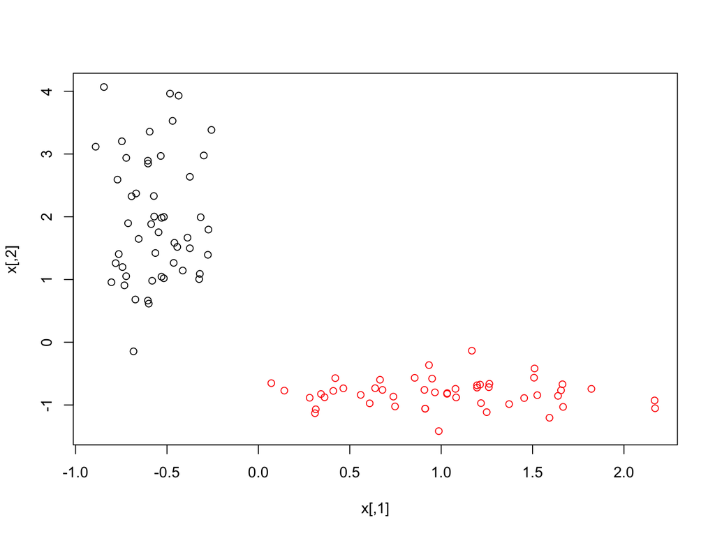

```r
#From the **deepnet** package by Xiao Rong. First train the model using one hidden layer.
Var1 <- c(rnorm(50, 1, 0.5), rnorm(50, -0.6, 0.2))
Var2 <- c(rnorm(50, -0.8, 0.2), rnorm(50, 2, 1))
x <- matrix(c(Var1, Var2), nrow = 100, ncol = 2)
y <- c(rep(1, 50), rep(0, 50))
plot(x,col=y+1)
```

```r
nn <- nn.train(x, y, hidden = c(5))
```

### Prediction

```r
#Next, predict the model. This is in-sample.
test_Var1 <- c(rnorm(50, 1, 0.5), rnorm(50, -0.6, 0.2))
test_Var2 <- c(rnorm(50, -0.8, 0.2), rnorm(50, 2, 1))
test_x <- matrix(c(test_Var1, test_Var2), nrow = 100, ncol = 2)
yy <- nn.predict(nn, test_x)
```

### Test Predictive Ability of the Model

```r
#The output is just a number that is higher for one class and lower for another.
#One needs to separate these to get groups.
yhat = matrix(0,length(yy),1)
yhat[which(yy > mean(yy))] = 1
yhat[which(yy <= mean(yy))] = 0
print(table(yhat,y))
```

```
##     y
## yhat  0  1
##    0 50  0
##    1  0 50
```

### Prediction Error

```r
#Testing the results.
err <- nn.test(nn, test_x, y, t=mean(yy))
print(err)
```

```
## [1] 0
```

# Cancer dataset

Now we’ll try the Breast Cancer data set. First we use the NN in the **deepnet** package.

```r
library(mlbench)
data("BreastCancer")
head(BreastCancer)
```

```
##        Id Cl.thickness Cell.size Cell.shape Marg.adhesion Epith.c.size
## 1 1000025            5         1          1             1            2
## 2 1002945            5         4          4             5            7
## 3 1015425            3         1          1             1            2
## 4 1016277            6         8          8             1            3
## 5 1017023            4         1          1             3            2
## 6 1017122            8        10         10             8            7
##   Bare.nuclei Bl.cromatin Normal.nucleoli Mitoses     Class
## 1           1           3               1       1    benign
## 2          10           3               2       1    benign
## 3           2           3               1       1    benign
## 4           4           3               7       1    benign
## 5           1           3               1       1    benign
## 6          10           9               7       1 malignant
```

```r
BreastCancer = BreastCancer[which(complete.cases(BreastCancer)==TRUE),]
```

```r
y = as.matrix(BreastCancer[,11])
y[which(y=="benign")] = 0
y[which(y=="malignant")] = 1
y = as.numeric(y)
x = as.numeric(as.matrix(BreastCancer[,2:10]))
x = matrix(as.numeric(x),ncol=9)
nn <- nn.train(x, y, hidden = c(5))
yy = nn.predict(nn, x)

yhat = matrix(0,length(yy),1)
yhat[which(yy > mean(yy))] = 1
yhat[which(yy <= mean(yy))] = 0
print(table(y,yhat))
```

```
##    yhat
## y     0   1
##   0 423  21
##   1   5 234
```

### Compare to a simple NN

It does really well. Now we compare it to a simple neural net.

```r
library(neuralnet)
df = data.frame(cbind(x,y))
nn = neuralnet(y~V1+V2+V3+V4+V5+V6+V7+V8+V9,data=df,hidden = 5)
yy = nn$net.result[[1]]
yhat = matrix(0,length(y),1)
yhat[which(yy > mean(yy))] = 1
yhat[which(yy <= mean(yy))] = 0
print(table(y,yhat))
```

```
##    yhat
## y     0   1
##   0 434  10
##   1   0 239
```

Somehow, the **neuralnet** package appears to perform better. Which is interesting. But the deep learning net was not “deep” - it had only one hidden layer.

# Deeper Net: More Hidden Layers

Now we’ll try the **deepnet** function with two hidden layers.

```r
dnn <- sae.dnn.train(x, y, hidden = c(5,5))
```

```
## begin to train sae ......
```

```
## training layer 1 autoencoder ...
```

```
## training layer 2 autoencoder ...
```

```
## sae has been trained.
```

```
## begin to train deep nn ......
```

```
## deep nn has been trained.
```

```r
yy = nn.predict(dnn, x)

yhat = matrix(0,length(yy),1)
yhat[which(yy > mean(yy))] = 1
yhat[which(yy <= mean(yy))] = 0
print(table(y,yhat))
```

```
##    yhat
## y     0   1
##   0 333 111
##   1 239   0
```

This performs terribly. Maybe there is something wrong here.

# Using h2o

Here we start up a server using all cores of the machine, and then use the h2o package’s deep learning toolkit to fit a model.

```r
library(h2o)
localH2O = h2o.init(ip="localhost", port = 54321,
                    startH2O = TRUE, nthreads=-1)
```

```
##  Connection successful!
##
## R is connected to the H2O cluster:
##     H2O cluster uptime:         20 minutes 52 seconds
##     H2O cluster version:        3.10.5.3
##     H2O cluster version age:    6 months and 30 days !!!
##     H2O cluster name:           H2O_started_from_R_srdas_chg102
##     H2O cluster total nodes:    1
##     H2O cluster total memory:   1.73 GB
##     H2O cluster total cores:    4
##     H2O cluster allowed cores:  4
##     H2O cluster healthy:        TRUE
##     H2O Connection ip:          localhost
##     H2O Connection port:        54321
##     H2O Connection proxy:       NA
##     H2O Internal Security:      FALSE
##     R Version:                  R version 3.3.2 (2016-10-31)
```

```r
train <- h2o.importFile("DSTMAA_data/BreastCancer.csv")
test <- h2o.importFile("DSTMAA_data/BreastCancer.csv")
y = names(train)[11]
x = names(train)[1:10]


train[,y] = as.factor(train[,y])
test[,y] = as.factor(train[,y])

model = h2o.deeplearning(x=x,
                         y=y,
                         training_frame=train,
                         validation_frame=test,
                         distribution = "multinomial",
                         activation = "RectifierWithDropout",
                         hidden = c(10,10,10,10),
                         input_dropout_ratio = 0.2,
                         l1 = 1e-5,
                         epochs = 50)
model
```

```
## Model Details:
## ==============
##
## H2OBinomialModel: deeplearning
## Model ID:  DeepLearning_model_R_1517291670789_7
## Status of Neuron Layers: predicting Class, 2-class classification, multinomial distribution, CrossEntropy loss, 462 weights/biases, 12.6 KB, 34,150 training samples, mini-batch size 1
##   layer units             type dropout       l1       l2 mean_rate
## 1     1    10            Input 20.00 %
## 2     2    10 RectifierDropout 50.00 % 0.000010 0.000000  0.001345
## 3     3    10 RectifierDropout 50.00 % 0.000010 0.000000  0.001072
## 4     4    10 RectifierDropout 50.00 % 0.000010 0.000000  0.001020
## 5     5    10 RectifierDropout 50.00 % 0.000010 0.000000  0.004167
## 6     6     2          Softmax         0.000010 0.000000  0.001339
##   rate_rms momentum mean_weight weight_rms mean_bias bias_rms
## 1
## 2 0.001474 0.000000    0.029354   0.371106  0.556498 0.133408
## 3 0.000764 0.000000   -0.011063   0.361597  0.813748 0.197719
## 4 0.000719 0.000000    0.011040   0.323018  0.979817 0.225309
## 5 0.008162 0.000000   -0.076486   0.374557  0.660365 0.247286
## 6 0.000483 0.000000    0.105638   1.641735  0.001251 0.047679
##
##
## H2OBinomialMetrics: deeplearning
## ** Reported on training data. **
## ** Metrics reported on full training frame **
##
## MSE:  0.02600726032
## RMSE:  0.1612676667
## LogLoss:  0.1022787108
## Mean Per-Class Error:  0.02220211844
## AUC:  0.9948546873
## Gini:  0.9897093746
##
## Confusion Matrix (vertical: actual; across: predicted) for F1-optimal threshold:
##           benign malignant    Error     Rate
## benign       428        16 0.036036  =16/444
## malignant      2       237 0.008368   =2/239
## Totals       430       253 0.026354  =18/683
##
## Maximum Metrics: Maximum metrics at their respective thresholds
```

[output cut: 29 more lines]

```
##
## Maximum Metrics: Maximum metrics at their respective thresholds
##                         metric threshold    value idx
## 1                       max f1  0.157355 0.963415 216
## 2                       max f2  0.098968 0.981039 220
## 3                 max f0point5  0.857280 0.956980 188
## 4                 max accuracy  0.194662 0.973646 212
## 5                max precision  0.993040 1.000000   0
## 6                   max recall  0.038544 1.000000 236
## 7              max specificity  0.993040 1.000000   0
## 8             max absolute_mcc  0.157355 0.943779 216
## 9   max min_per_class_accuracy  0.209653 0.970721 209
## 10 max mean_per_class_accuracy  0.157355 0.977798 216
##
## Gains/Lift Table: Extract with `h2o.gainsLift(<model>, <data>)` or `h2o.gainsLift(<model>, valid=<T/F>, xval=<T/F>)`
```

The h2o deep learning package does very well.

```r
#h2o.shutdown(prompt=FALSE)
```

# Character Recognition

We use the MNIST dataset

```r
library(h2o)
localH2O = h2o.init(ip="localhost", port = 54321,
                    startH2O = TRUE)
```

```
##  Connection successful!
##
## R is connected to the H2O cluster:
##     H2O cluster uptime:         20 minutes 56 seconds
##     H2O cluster version:        3.10.5.3
##     H2O cluster version age:    6 months and 30 days !!!
##     H2O cluster name:           H2O_started_from_R_srdas_chg102
##     H2O cluster total nodes:    1
##     H2O cluster total memory:   1.73 GB
##     H2O cluster total cores:    4
##     H2O cluster allowed cores:  4
##     H2O cluster healthy:        TRUE
##     H2O Connection ip:          localhost
##     H2O Connection port:        54321
##     H2O Connection proxy:       NA
##     H2O Internal Security:      FALSE
##     R Version:                  R version 3.3.2 (2016-10-31)
```

```r
## Import MNIST CSV as H2O
train <- h2o.importFile("DSTMAA_data/train.csv")
test <- h2o.importFile("DSTMAA_data/test.csv")
#summary(train)
#summary(test)
```

```r
y <- "C785"
x <- setdiff(names(train), y)
train[,y] <- as.factor(train[,y])
test[,y] <- as.factor(test[,y])

# Train a Deep Learning model and validate on a test set
model <- h2o.deeplearning(x = x,
                          y = y,
                          training_frame = train,
                          validation_frame = test,
                          distribution = "multinomial",
                          activation = "RectifierWithDropout",
                          hidden = c(100,100,100),
                          input_dropout_ratio = 0.2,
                          l1 = 1e-5,
                          epochs = 20)
model
```

```
## Model Details:
## ==============
##
## H2OMultinomialModel: deeplearning
## Model ID:  DeepLearning_model_R_1517291670789_12
## Status of Neuron Layers: predicting C785, 10-class classification, multinomial distribution, CrossEntropy loss, 93,010 weights/biases, 1.3 MB, 1,214,312 training samples, mini-batch size 1
##   layer units             type dropout       l1       l2 mean_rate
## 1     1   717            Input 20.00 %
## 2     2   100 RectifierDropout 50.00 % 0.000010 0.000000  0.049603
## 3     3   100 RectifierDropout 50.00 % 0.000010 0.000000  0.000416
## 4     4   100 RectifierDropout 50.00 % 0.000010 0.000000  0.000894
## 5     5    10          Softmax         0.000010 0.000000  0.006029
##   rate_rms momentum mean_weight weight_rms mean_bias bias_rms
## 1
## 2 0.114618 0.000000    0.035106   0.107527 -0.336221 0.235452
## 3 0.000190 0.000000   -0.033283   0.098660  0.817441 0.136761
## 4 0.000453 0.000000   -0.026990   0.103261  0.546840 0.126160
## 5 0.011789 0.000000   -0.499804   0.716823 -2.771059 0.452309
##
##
## H2OMultinomialMetrics: deeplearning
## ** Reported on training data. **
## ** Metrics reported on temporary training frame with 10067 samples **
##
## Training Set Metrics:
## =====================
##
## MSE: (Extract with `h2o.mse`) 0.03177031071
## RMSE: (Extract with `h2o.rmse`) 0.1782422809
## Logloss: (Extract with `h2o.logloss`) 0.1183024109
## Mean Per-Class Error: 0.03731151689
## Confusion Matrix: Extract with `h2o.confusionMatrix(<model>,train = TRUE)`)
## =========================================================================
## Confusion Matrix: Row labels: Actual class; Column labels: Predicted class
##           0    1    2   3   4   5    6    7   8   9  Error           Rate
## 0      1016    0    4   1   1   3    8    0   3   0 0.0193 =   20 / 1,036
## 1         0 1130    6   3   1   1    1    6   4   0 0.0191 =   22 / 1,152
## 2         4    1  974   5   7   0   14    7   6   1 0.0442 =   45 / 1,019
## 3         1    1   15 958   0  16    0   12  12   3 0.0589 =   60 / 1,018
## 4         1    1    6   0 935   1    3    1   0  14 0.0281 =     27 / 962
```

[output cut: 50 more lines]

```
##
## Hit Ratio Table: Extract with `h2o.hit_ratio_table(<model>,valid = TRUE)`
## =======================================================================
## Top-10 Hit Ratios:
##     k hit_ratio
## 1   1  0.958400
## 2   2  0.985100
## 3   3  0.992100
## 4   4  0.995500
## 5   5  0.998000
## 6   6  0.998700
## 7   7  0.999300
## 8   8  0.999500
## 9   9  0.999800
## 10 10  1.000000
```

# Deep Learning with TensorFlow

```r
library(tensorflow)
library(kerasR)
```

Set up data

```r
tf_train <- read.csv("DSTMAA_data/BreastCancer.csv")
tf_test <- read.csv("DSTMAA_data/BreastCancer.csv")

X_train = as.matrix(tf_train[,2:10])
X_test = as.matrix(tf_test[,2:10])
y_train = as.matrix(tf_train[,11])
y_test = as.matrix(tf_test[,11])

idx = which(y_train=="benign"); y_train[idx]=0; y_train[-idx]=1; y_train=as.integer(y_train)
idx = which(y_test=="benign"); y_test[idx]=0; y_test[-idx]=1; y_test=as.integer(y_test)

Y_train <- to_categorical(y_train,2)
```

Set up and compile the model

```r
n_units = 512

mod <- Sequential()
mod$add(Dense(units = n_units, input_shape = dim(X_train)[2]))
mod$add(LeakyReLU())
mod$add(Dropout(0.25))

mod$add(Dense(units = n_units))
mod$add(LeakyReLU())
mod$add(Dropout(0.25))

mod$add(Dense(units = n_units))
mod$add(LeakyReLU())
mod$add(Dropout(0.25))

mod$add(Dense(units = n_units))
mod$add(LeakyReLU())
mod$add(Dropout(0.25))

mod$add(Dense(units = n_units))
mod$add(LeakyReLU())
mod$add(Dropout(0.25))

mod$add(Dense(2))
mod$add(Activation("softmax"))

keras_compile(mod, loss = 'categorical_crossentropy', optimizer = RMSprop())
```

Fit the deep learning net

```r
keras_fit(mod, X_train, Y_train, batch_size = 32, epochs = 15, verbose = 1,
validation_split = 1.0)
```

Check accuracy and predictions.

```r
#In-sample
Y_train_hat <- keras_predict_classes(mod, X_train)
table(y_train, Y_train_hat)
```

```
##        Y_train_hat
## y_train   0   1
##       0 440   4
##       1  35 204
```

```r
print(c("Mean in-sample accuracy = ",mean(y_train == Y_train_hat)))
```

```
## [1] "Mean in-sample accuracy = " "0.94289897510981"
```

```r
#Validation
Y_test_hat <- keras_predict_classes(mod, X_test)
table(y_test, Y_test_hat)
```

```
##       Y_test_hat
## y_test   0   1
##      0 440   4
##      1  35 204
```

```r
print(c("Mean validation accuracy = ",mean(y_test == Y_test_hat)))
```

```
## [1] "Mean validation accuracy = " "0.94289897510981"
```

# The MNIST Example: The “Hello World” of Deep Learning

Load in the MNIST data. Example taken from: https://cran.r-project.org/web/packages/kerasR/vignettes/introduction.html

```r
library(data.table)
train = as.data.frame(fread("DSTMAA_data/train.csv"))
```

```
##
Read 50.0% of 60000 rows
Read 60000 rows and 785 (of 785) columns from 0.102 GB file in 00:00:04
```

```r
test = as.data.frame(fread("DSTMAA_data/test.csv"))
#mnist <- load_mnist()
X_train <- as.matrix(train[,-1])
Y_train <- as.matrix(train[,785])
X_test <- as.matrix(test[,-1])
Y_test <- as.matrix(test[,785])
dim(X_train)
```

```
## [1] 60000   784
```

# Normalization

Now we normalize the values, which are pixel intensities ranging in $(0,255)$.

```r
X_train <- array(X_train, dim = c(dim(X_train)[1], prod(dim(X_train)[-1]))) / 255
X_test <- array(X_test, dim = c(dim(X_test)[1], prod(dim(X_test)[-1]))) / 255
```

Convert the $Y$ variable to categorical.

```r
Y_train <- to_categorical(Y_train, 10)
```

# Construct the Deep Learning Net

Now create the model in Keras.

```r
n_units = 100  ## tf example is 512, acc=95%, with 100, acc=96%

mod <- Sequential()
mod$add(Dense(units = n_units, input_shape = dim(X_train)[2]))
mod$add(LeakyReLU())
mod$add(Dropout(0.25))

mod$add(Dense(units = n_units))
mod$add(LeakyReLU())
mod$add(Dropout(0.25))

mod$add(Dense(units = n_units))
mod$add(LeakyReLU())
mod$add(Dropout(0.25))

mod$add(Dense(10))
mod$add(Activation("softmax"))
```

# Compilation

Then, compile the model.

```r
keras_compile(mod, loss = 'categorical_crossentropy', optimizer = RMSprop())
```

# Fit the Model

Now run the model to get a fitted deep learning network.

```r
keras_fit(mod, X_train, Y_train, batch_size = 32, epochs = 5, verbose = 1,
validation_split = 0.1)
```

# Quality of Fit

Check accuracy and predictions.

```r
Y_test_hat <- keras_predict_classes(mod, X_test)
table(Y_test, Y_test_hat)
```

```
##       Y_test_hat
## Y_test    0    1    2    3    4    5    6    7    8    9
##      0  964    0    1    1    1    1    7    2    2    1
##      1    0 1117    5    2    0    1    4    0    6    0
##      2    7    1  988    6    9    0    4   11    5    1
##      3    2    0   13  960    0   17    0    9    8    1
##      4    1    2    6    1  936    0    9    7    6   14
##      5    5    1    1   17    1  837   21    1    7    1
##      6    5    3    0    0    7    5  935    0    3    0
##      7    2    5   12    8    0    0    0  996    0    5
##      8    8    1    5    6    4    7   12    9  920    2
##      9    3   10    1   14   16   11    2   15    7  930
```

```r
mean(Y_test == as.matrix(Y_test_hat))
```

```
## [1] 0.9583
```

# MxNet Package

The package needs the correct version of Java to run.

```r
#From R-bloggers
require(mlbench)
## Loading required package: mlbench
require(mxnet)
## Loading required package: mxnet
## Loading required package: methods
data(Sonar, package="mlbench")

Sonar[,61] = as.numeric(Sonar[,61])-1
train.ind = c(1:50, 100:150)
train.x = data.matrix(Sonar[train.ind, 1:60])
train.y = Sonar[train.ind, 61]
test.x = data.matrix(Sonar[-train.ind, 1:60])
test.y = Sonar[-train.ind, 61]

mx.set.seed(0)
model <- mx.mlp(train.x, train.y, hidden_node=10, out_node=2, out_activation="softmax", num.round=100, array.batch.size=15, learning.rate=0.25, momentum=0.9,                eval.metric=mx.metric.accuracy)
```

```
## Start training with 1 devices
## [1] Train-accuracy=0.488888888888889
## [2] Train-accuracy=0.457142857142857
## [3] Train-accuracy=0.447619047619048
## [4] Train-accuracy=0.59047619047619
## [5] Train-accuracy=0.6
## [6] Train-accuracy=0.638095238095238
## [7] Train-accuracy=0.647619047619048
## [8] Train-accuracy=0.809523809523809
## [9] Train-accuracy=0.790476190476191
## [10] Train-accuracy=0.809523809523809
## [11] Train-accuracy=0.771428571428571
## [12] Train-accuracy=0.771428571428571
## [13] Train-accuracy=0.79047619047619
## [14] Train-accuracy=0.79047619047619
```

[output cut: 86 more lines]

```r
preds = predict(model, test.x)
## Auto detect layout of input matrix, use rowmajor..
pred.label = max.col(t(preds))-1
table(pred.label, test.y)
```

```
##           test.y
## pred.label  0  1
##          0 23 11
##          1 37 36
```

### Cancer Data

Now an example using the BreastCancer data set.

```r
data("BreastCancer")
BreastCancer = BreastCancer[which(complete.cases(BreastCancer)==TRUE),]

y = as.matrix(BreastCancer[,11])
y[which(y=="benign")] = 0
y[which(y=="malignant")] = 1
y = as.numeric(y)
x = as.numeric(as.matrix(BreastCancer[,2:10]))
x = matrix(as.numeric(x),ncol=9)

train.x = x
train.y = y
test.x = x
test.y = y

mx.set.seed(0)
model <- mx.mlp(train.x, train.y, hidden_node=5, out_node=10, out_activation="softmax", num.round=30, array.batch.size=15, learning.rate=0.07, momentum=0.9,                eval.metric=mx.metric.accuracy)
```

```
## Start training with 1 devices
## [1] Train-accuracy=0.61037037037037
## [2] Train-accuracy=0.872463768115942
## [3] Train-accuracy=0.921739130434782
## [4] Train-accuracy=0.920289855072464
## [5] Train-accuracy=0.842028985507246
## [6] Train-accuracy=0.908695652173913
## [7] Train-accuracy=0.926086956521739
## [8] Train-accuracy=0.907246376811594
## [9] Train-accuracy=0.933333333333333
## [10] Train-accuracy=0.9
## [11] Train-accuracy=0.939130434782608
## [12] Train-accuracy=0.939130434782608
## [13] Train-accuracy=0.947826086956521
## [14] Train-accuracy=0.915942028985507
```

[output cut: 16 more lines]

```r
preds = predict(model, test.x)
## Auto detect layout of input matrix, use rowmajor..
pred.label = max.col(t(preds))-1
table(pred.label, test.y)
```

```
##           test.y
## pred.label   0   1
##          0 410  16
##          1  34 223
```

# Visualization of Neural Nets using Tensorflow

See: http://playground.tensorflow.org/

# Convolutional Neural Nets (CNNs)

To be written

See: https://adeshpande3.github.io/adeshpande3.github.io/A-Beginner's-Guide-To-Understanding-Convolutional-Neural-Networks/

# Recurrent Neural Nets (RNNs)

To be written